# Enriched author metadata from WikiData

Peeter Tinits

2025-11-14

## Overview

I made a first pass through linking HPB authors with Wikidata to see what’s there. We can do a more proper run through other datasets for author metadata enrichment down the line.

I used the Wikidata API via the WikidataR package, linking the author names with entries on humans under the same name and confirming the matches via birth dates. This gave quite a lot of results, HPB had quite a lot of missing birth dates though, so I think even more can be linked.

For the top 20k authors we have been working with, it found 75% of the authors.

Todo list:

- Link also name matches that could not match a birth date with a few more rules.
- Either via fuzzy birth year +/- 2 years. Did only exact matches for now.
- Or by seeing if the first publication in the dataset was during the lifetime of the wikipedia entry.

## Data overviews

The following data overviews may be useful. They are as a share of all authors that have more than 20 editions under their name, some have a birth date on them, some don’t.

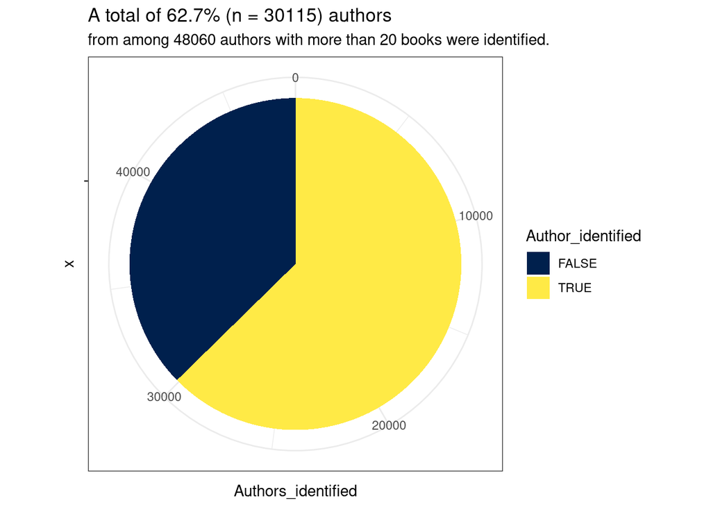

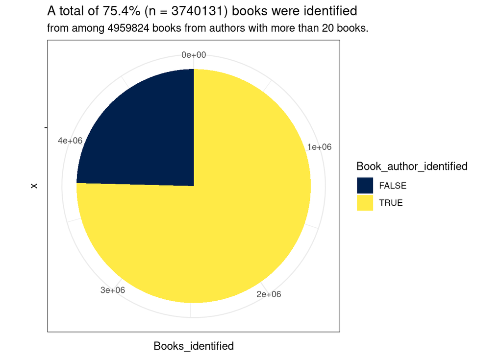

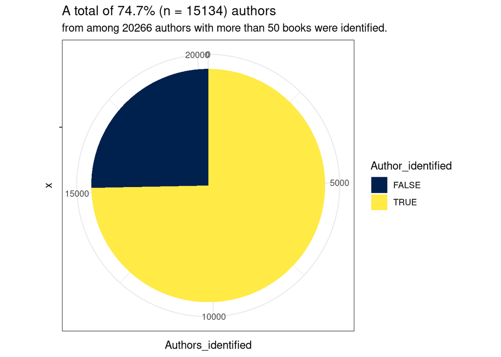

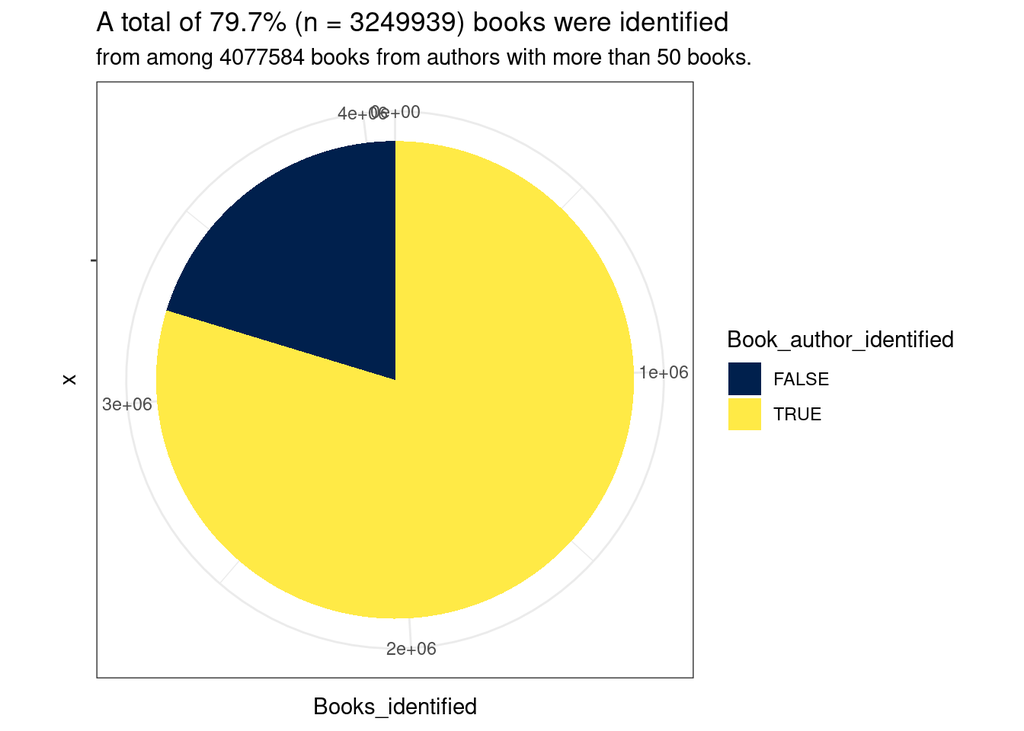

## Geolocations

There are a few fields here that are also linked with geocoded locations in Wikidata. The detail varies here, but it can give useful overviews. For best use, probably the exact coordinates + modern world map is better than the historical entities that are often linked in the dataset. In this overview are presented 1) birth place, 2) death place, 3) educated at. Residence and place of work may also be meaningful too for analysis.

## Birth places

Then the author birth places and death on the map. Lumped them together with some 10km distance, but be vary of many points in almost the same place. Easy to change the rounding parameter here for example. E.g. the rounding parameter to 0 gives a nice 100km grid.

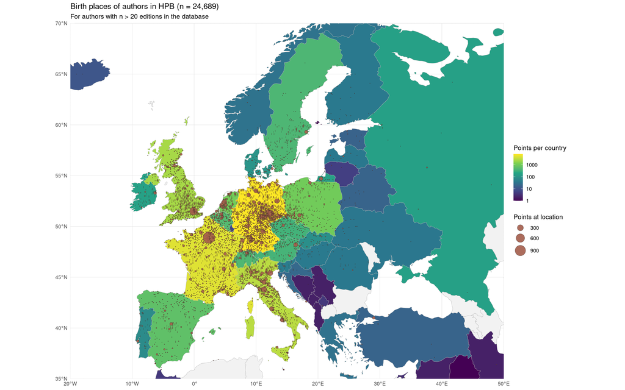

### Death places

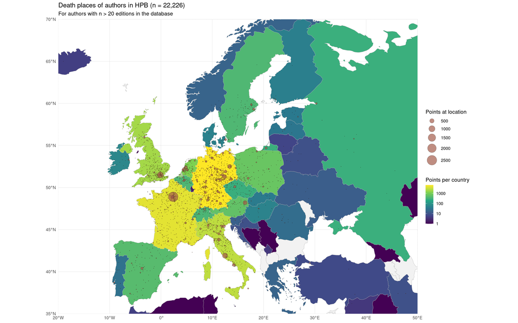

### Educated at

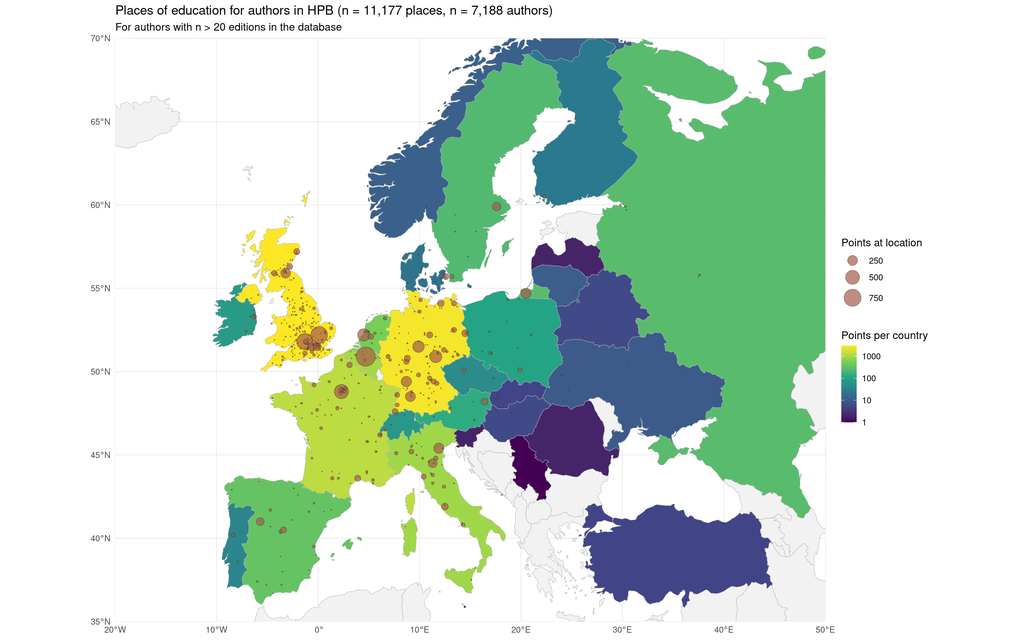

## The available data fields per author

Something about the grouping of author names is still off though. I think the repeating names mean that the authors had different birth dates in HPB

| column | authors | share_of_authors | top_values |
| --- | --- | --- | --- |
| author_id_3 | 48335 | 100% | 4 - John Potter-1673-1747, 4 - John Potter-1674-1747, 4 - John Potter-4-1747, 3 - Agostino Nifo-1473-1538, 3 - Agostino Nifo-1473-1545 |
| primary_author_name.x | 48335 | 100% | 31641 - , 14 - Johannes, 10 - Karl, 9 - Petrus, 7 - Agostino Nifo |
| N.x | 48335 | 100% | 2052 - 21, 1807 - 22, 1683 - 23, 1578 - 24, 1467 - 25 |
| result_nr | 30390 | 63% | 3 - 13871, 3 - 17725, 3 - 20223, 3 - 21095, 3 - 24002 |
| item_nr | 30390 | 63% | 25736 - 1, 2380 - 2, 868 - 3, 468 - 4, 260 - 5 |
| query | 30390 | 63% | 12 - John Potter, 9 - Cornelius Schrevelius, 9 - William Rowley, 8 - Garcilaso De La Vega, 7 - Aldo Manuzio |
| country of citizenship | 19203 | 40% | 4479 - Germany, 4333 - France, 569 - Kingdom of Great Britain, 541 - Dutch Republic, 537 - Spain |
| country of citizenship code | 19203 | 40% | 4479 - Q183, 4336 - Q142, 569 - Q161885, 541 - Q170072, 537 - Q29 |
| date of birth | 30390 | 63% | 184 - 1755, 182 - 1754, 175 - 1751, 175 - 1753, 174 - 1772 |
| date of death | 30027 | 62% | 189 - 1832, 185 - 1835, 175 - 1831, 170 - 1826, 169 - 1829 |
| educated at | 8341 | 17% | 317 - Martin Luther University Halle-Wittenberg, 287 - Leipzig University, 207 - Friedrich Schiller University Jena, 180 - University of Göttingen, 179 - Leiden University |
| educated at code | 8341 | 17% | 329 - Q32120, 291 - Q154804, 211 - Q154561, 190 - Q156598, 189 - Q152838 |
| field of work | 5147 | 11% | 260 - botany, 147 - theology, 132 - medicine, 126 - philosophy, 93 - law |
| genre | 840 | 2% | 211 - opera, 59 - poetry, 57 - classical music, 57 - portrait, 16 - landscape painting |
| languages spoken, written or signed | 22057 | 46% | 6150 - German, 4289 - French, 2192 - English, 2147 - Latin, 1562 - Italian |
| notable work | 2010 | 4% | 10 - Summa Theologica; Summa contra Gentiles; De regimine principum; Quinque viae; Commentary on Aristotle’s Metaphysics, 9 - De homine; De vegetabilis et plantis libri septem; De mineralibus; Secreta… |
| occupation | 28761 | 60% | 975 - theologian, 969 - writer, 635 - physician, 613 - jurist, 468 - theologian; university teacher |
| place of birth | 23763 | 49% | 1030 - Paris, 321 - London, 250 - Leipzig, 201 - Florence, 189 - Amsterdam |
| place of birth code | 23763 | 49% | 1030 - Q90, 321 - Q84, 250 - Q2079, 201 - Q2044, 189 - Q727 |
| place of death | 21433 | 44% | 2202 - Paris, 669 - Rome, 649 - London, 408 - Vienna, 394 - Berlin |
| place of death code | 21433 | 44% | 2201 - Q90, 669 - Q220, 647 - Q84, 408 - Q1741, 394 - Q64 |
| position held | 5832 | 12% | 229 - rector, 132 - abbot, 131 - rector magnificus of Leiden University, 85 - rector of Utrecht University, 84 - Geheimrat |
| religion or worldview | 7411 | 15% | 2221 - Catholic Church, 1951 - Lutheranism, 995 - Catholicism, 657 - Anglicanism, 548 - Protestantism |
| residence | 807 | 2% | 55 - France, 41 - Germany, 25 - England, 18 - Netherlands, 17 - Kingdom of Prussia |
| residence code | 807 | 2% | 58 - Q142, 41 - Q183, 25 - Q21, 18 - Q55, 17 - Q27306 |
| sex or gender | 30262 | 63% | 29856 - male, 401 - female, 2 - trans woman; intersex, 1 - female; male |
| work location | 5590 | 12% | 592 - Paris, 229 - Leipzig, 171 - Tübingen, 152 - London, 107 - Frankfurt (Oder) |
| work location code | 5590 | 12% | 614 - Q90, 231 - Q2079, 172 - Q3806, 169 - Q84, 107 - Q4024 |
| work period (end) | 511 | 1% | 8 - 1813, 8 - 1824, 7 - 1598, 7 - 1763, 7 - 1821 |
| work period (start) | 684 | 1% | 12 - 1700, 11 - 1756, 9 - 1780, 9 - 1800, 8 - 1544 |
| writing language | 5604 | 12% | 1857 - French, 1180 - English, 964 - German, 468 - Italian, 420 - Latin |
| death_year | 30131 | 62% | 206 - 1832, 199 - 1835, 195 - 1826, 189 - 1829, 188 - 1831 |
| primary_author_name.y | 14291 | 30% | 6 - Agostino Nifo, 6 - Henri Estienne, 6 - John Fisher, 6 - Thomas D’aquin, 6 - Thomas Stackhouse |
| N.y | 30390 | 63% | 965 - 21, 814 - 22, 812 - 23, 780 - 24, 746 - 25 |
| formatted_birth_year | 30390 | 63% | 202 - 1755, 197 - 1754, 195 - 1772, 194 - 1752, 188 - 1750 |
| years | 30390 | 63% | 15 - -1740-1814, 14 - -1751-1825, 13 - -1758-1831, 13 - -1782-1848, 12 - -1699-1768 |
| birth_year | 30390 | 63% | 210 - 1755, 209 - 1750, 204 - 1752, 203 - 1754, 200 - 1740 |
| date_of_birth_confirmed | 30390 | 63% | 28784 - TRUE, 1604 - FALSE |
| formatted_death_year | 30390 | 63% | 363 - NA, 202 - 1832, 199 - 1835, 187 - 1831, 184 - 1829 |
| date_of_death_confirmed | 30390 | 63% | 29123 - TRUE, 1265 - FALSE |
| author_id_3_merged | 30390 | 63% | 12 - John Potter-1673-1747, 9 - Cornelius Schrevelius-1615-1664, 9 - William Rowley-1742-1806, 7 - William Chambers-1723-1793, 6 - Agostino Nifo-1473-1538 |